# Descriptive Statistics and Understanding the Data

```python
import pandas as pd
import matplotlib.pyplot as plt
from pandasql import sqldf
pysqldf = lambda q: sqldf(q, globals())

%store -r athlete_events
%store -r summer_games
%store -r winter_games
%store -r female
%store -r male
```

```python
athlete_events.head()
```

|  | ID | Name | Sex | Age | Height | Weight | Team | NOC | Games | Year | Season | City | Sport | Event | Medal |
| --- | --- | --- | --- | --- | --- | --- | --- | --- | --- | --- | --- | --- | --- | --- | --- |
| 0 | 1 | A Dijiang | M | 24.0 | 180.0 | 80.0 | China | CHN | 1992 Summer | 1992 | Summer | Barcelona | Basketball | Basketball Men's Basketball | NaN |
| 1 | 2 | A Lamusi | M | 23.0 | 170.0 | 60.0 | China | CHN | 2012 Summer | 2012 | Summer | London | Judo | Judo Men's Extra-Lightweight | NaN |
| 2 | 3 | Gunnar Nielsen Aaby | M | 24.0 | NaN | NaN | Denmark | DEN | 1920 Summer | 1920 | Summer | Antwerpen | Football | Football Men's Football | NaN |
| 3 | 4 | Edgar Lindenau Aabye | M | 34.0 | NaN | NaN | Denmark/Sweden | DEN | 1900 Summer | 1900 | Summer | Paris | Tug-Of-War | Tug-Of-War Men's Tug-Of-War | Gold |
| 4 | 5 | Christine Jacoba Aaftink | F | 21.0 | 185.0 | 82.0 | Netherlands | NED | 1988 Winter | 1988 | Winter | Calgary | Speed Skating | Speed Skating Women's 500 metres | NaN |

```python
summer_games.head()
```

|  | ID | Name | Sex | Age | Height | Weight | Team | NOC | Games | Year | Season | City | Sport | Event | Medal |
| --- | --- | --- | --- | --- | --- | --- | --- | --- | --- | --- | --- | --- | --- | --- | --- |
| 0 | 1 | A Dijiang | M | 24.0 | 180.0 | 80.0 | China | CHN | 1992 Summer | 1992 | Summer | Barcelona | Basketball | Basketball Men's Basketball | None |
| 1 | 2 | A Lamusi | M | 23.0 | 170.0 | 60.0 | China | CHN | 2012 Summer | 2012 | Summer | London | Judo | Judo Men's Extra-Lightweight | None |
| 2 | 3 | Gunnar Nielsen Aaby | M | 24.0 | NaN | NaN | Denmark | DEN | 1920 Summer | 1920 | Summer | Antwerpen | Football | Football Men's Football | None |
| 3 | 4 | Edgar Lindenau Aabye | M | 34.0 | NaN | NaN | Denmark/Sweden | DEN | 1900 Summer | 1900 | Summer | Paris | Tug-Of-War | Tug-Of-War Men's Tug-Of-War | Gold |
| 4 | 8 | Cornelia "Cor" Aalten (-Strannood) | F | 18.0 | 168.0 | NaN | Netherlands | NED | 1932 Summer | 1932 | Summer | Los Angeles | Athletics | Athletics Women's 100 metres | None |

```python
winter_games.head()
```

|  | ID | Name | Sex | Age | Height | Weight | Team | NOC | Games | Year | Season | City | Sport | Event | Medal |
| --- | --- | --- | --- | --- | --- | --- | --- | --- | --- | --- | --- | --- | --- | --- | --- |
| 0 | 5 | Christine Jacoba Aaftink | F | 21.0 | 185.0 | 82.0 | Netherlands | NED | 1988 Winter | 1988 | Winter | Calgary | Speed Skating | Speed Skating Women's 500 metres | None |
| 1 | 5 | Christine Jacoba Aaftink | F | 21.0 | 185.0 | 82.0 | Netherlands | NED | 1988 Winter | 1988 | Winter | Calgary | Speed Skating | Speed Skating Women's 1,000 metres | None |
| 2 | 5 | Christine Jacoba Aaftink | F | 25.0 | 185.0 | 82.0 | Netherlands | NED | 1992 Winter | 1992 | Winter | Albertville | Speed Skating | Speed Skating Women's 500 metres | None |
| 3 | 5 | Christine Jacoba Aaftink | F | 25.0 | 185.0 | 82.0 | Netherlands | NED | 1992 Winter | 1992 | Winter | Albertville | Speed Skating | Speed Skating Women's 1,000 metres | None |
| 4 | 5 | Christine Jacoba Aaftink | F | 27.0 | 185.0 | 82.0 | Netherlands | NED | 1994 Winter | 1994 | Winter | Lillehammer | Speed Skating | Speed Skating Women's 500 metres | None |

```python
#Calculating the ratios for Men vs Women
# Total Ratio
total_ratio = pysqldf('''SELECT Sex,
                                COUNT(*) Total_Count,
                                COUNT(*) * 100.00 / SUM(COUNT(*)) OVER () AS ratio
                                FROM athlete_events
                                GROUP BY sex''')

#Summer games ratio
summer_ratio = pysqldf('''SELECT Sex,
                                COUNT(*) Total_Count,
                                COUNT(*) * 100.00 / SUM(COUNT(*)) OVER () AS ratio
                                FROM summer_games
                                GROUP BY sex''')

#Winter games ratio
winter_ratio = pysqldf('''SELECT Sex,
                                COUNT(*) Total_Count,
                                COUNT(*) * 100.00 / SUM(COUNT(*)) OVER () AS ratio
                                FROM winter_games
                                GROUP BY sex''')
```

```python
total_ratio.head()
```

|  | Sex | Total_Count | ratio |
| --- | --- | --- | --- |
| 0 | F | 74522 | 27.487127 |
| 1 | M | 196594 | 72.512873 |

```python
summer_ratio.head()
```

|  | Sex | Total_Count | ratio |
| --- | --- | --- | --- |
| 0 | F | 59443 | 26.709713 |
| 1 | M | 163109 | 73.290287 |

```python
winter_ratio.head()
```

|  | Sex | Total_Count | ratio |
| --- | --- | --- | --- |
| 0 | F | 15079 | 31.049749 |
| 1 | M | 33485 | 68.950251 |

```python
#Calculating the total average for Men and Women
total_averages = pysqldf('''SELECT Sex,
                                   AVG(Weight) Average_Weight,
                                   AVG(Height) Average_Height,
                                   AVG(Age) Average_Age
                            FROM athlete_events
                            GROUP BY Sex''')

#Calculating the Summer average for Men and Women
summer_averages = pysqldf('''SELECT Sex,
                                   AVG(Weight) Average_Weight,
                                   AVG(Height) Average_Height,
                                   AVG(Age) Average_Age
                            FROM summer_games
                            GROUP BY Sex''')

#Calculating the Winter average for Men and Women
winter_averages = pysqldf('''SELECT Sex,
                                   AVG(Weight) Average_Weight,
                                   AVG(Height) Average_Height,
                                   AVG(Age) Average_Age
                            FROM winter_games
                            GROUP BY Sex''')
```

```python
total_averages.head()
```

|  | Sex | Average_Weight | Average_Height | Average_Age |
| --- | --- | --- | --- | --- |
| 0 | F | 60.021252 | 167.839740 | 23.732881 |
| 1 | M | 75.743677 | 178.858463 | 26.277562 |

```python
summer_averages.head()
```

|  | Sex | Average_Weight | Average_Height | Average_Age |
| --- | --- | --- | --- | --- |
| 0 | F | 60.087644 | 168.169025 | 23.660997 |
| 1 | M | 75.604195 | 178.901874 | 26.443944 |

```python
winter_averages.head()
```

|  | Sex | Average_Weight | Average_Height | Average_Age |
| --- | --- | --- | --- | --- |
| 0 | F | 59.755156 | 166.528250 | 24.014398 |
| 1 | M | 76.357058 | 178.668699 | 25.504261 |

Next we're are going to dive into the medals awarded for the olympians and I will divide it into total medals, summer medals and winter medals. I am interesting in seeing how the medals are divided out, is there a significant area where males are being awarded the most medals? and vice versa is there a specific area where females are dominating medals.

```python
#Total view of each year showing Participants and the number of medals awarded
pysqldf('''SELECT Year,
                  COUNT(*) Participants,
                  SUM(CASE WHEN Medal IS NOT NULL THEN 1 ELSE 0 END) AS Total_Medals,
                  SUM(CASE WHEN Medal = 'Gold' THEN 1 ELSE 0 END) AS Gold_Medals,
                  SUM(CASE WHEN Medal = 'Silver' THEN 1 ELSE 0 END) AS Silver_Medals,
                  SUM(CASE WHEN Medal = 'Bronze' THEN 1 ELSE 0 END) AS Bronze_Medals
           FROM athlete_events
           GROUP BY Year''')
```

|  | Year | Participants | Total_Medals | Gold_Medals | Silver_Medals | Bronze_Medals |
| --- | --- | --- | --- | --- | --- | --- |
| 0 | 1896 | 380 | 143 | 62 | 43 | 38 |
| 1 | 1900 | 1936 | 604 | 201 | 228 | 175 |
| 2 | 1904 | 1301 | 486 | 173 | 163 | 150 |
| 3 | 1906 | 1733 | 458 | 157 | 156 | 145 |
| 4 | 1908 | 3101 | 831 | 294 | 281 | 256 |
| 5 | 1912 | 4040 | 941 | 326 | 315 | 300 |
| 6 | 1920 | 4292 | 1308 | 493 | 448 | 367 |
| 7 | 1924 | 5693 | 962 | 332 | 319 | 311 |
| 8 | 1928 | 5574 | 823 | 275 | 267 | 281 |
| 9 | 1932 | 3321 | 739 | 261 | 246 | 232 |
| 10 | 1936 | 7401 | 1025 | 348 | 347 | 330 |
| 11 | 1948 | 7480 | 987 | 330 | 332 | 325 |
| 12 | 1952 | 9358 | 1033 | 351 | 335 | 347 |
| 13 | 1956 | 6434 | 1043 | 353 | 342 | 348 |
| 14 | 1960 | 9235 | 1058 | 359 | 342 | 357 |
| 15 | 1964 | 9480 | 1215 | 408 | 406 | 401 |
| 16 | 1968 | 10479 | 1256 | 425 | 410 | 421 |
| 17 | 1972 | 11959 | 1414 | 474 | 455 | 485 |
| 18 | 1976 | 10502 | 1531 | 508 | 505 | 518 |
| 19 | 1980 | 8937 | 1602 | 529 | 531 | 542 |
| 20 | 1984 | 11588 | 1698 | 571 | 551 | 576 |
| 21 | 1988 | 14676 | 1845 | 607 | 601 | 637 |
| 22 | 1992 | 16413 | 2030 | 663 | 657 | 710 |
| 23 | 1994 | 3160 | 331 | 110 | 109 | 112 |
| 24 | 1996 | 13780 | 1842 | 608 | 605 | 629 |
| 25 | 1998 | 3605 | 440 | 145 | 145 | 150 |
| 26 | 2000 | 13821 | 2004 | 663 | 661 | 680 |
| 27 | 2002 | 4109 | 478 | 162 | 157 | 159 |
| 28 | 2004 | 13443 | 2001 | 664 | 660 | 677 |
| 29 | 2006 | 4382 | 526 | 176 | 175 | 175 |
| 30 | 2008 | 13602 | 2048 | 671 | 667 | 710 |
| 31 | 2010 | 4402 | 520 | 174 | 175 | 171 |
| 32 | 2012 | 12920 | 1941 | 632 | 630 | 679 |
| 33 | 2014 | 4891 | 597 | 202 | 197 | 198 |
| 34 | 2016 | 13688 | 2023 | 665 | 655 | 703 |

Check the amount of medals won as a % this time

```python
#Shows the % of medals won compared to the total participants e.g
# 2016 - 14.77% of participants received a medal
# 2016 - 4.85% of participants received a Gold medal
# 2016 - 4.78% of participants received a Silver medal
# 2016 - 5.13% of participants received a Bronze medal
total_ratio_medals = pysqldf('''SELECT Year,
                                        CAST(Total_Medals AS FLOAT) * 100 / Participants AS Total_Medals,
                                        CAST(Gold_Medals AS FLOAT) * 100 / Participants AS Gold_Medals,
                                        CAST(Silver_Medals AS FLOAT) * 100 / Participants AS Silver_Medals,
                                        CAST(Bronze_Medals AS FLOAT) * 100 / Participants AS Bronze_Medals
                                FROM
                                   (
                                   SELECT Year,
                                          COUNT(*) Participants,
                                          SUM(CASE WHEN Medal IS NOT NULL THEN 1 ELSE 0 END) AS Total_Medals,
                                          SUM(CASE WHEN Medal = 'Gold' THEN 1 ELSE 0 END) AS Gold_Medals,
                                          SUM(CASE WHEN Medal = 'Silver' THEN 1 ELSE 0 END) AS Silver_Medals,
                                          SUM(CASE WHEN Medal = 'Bronze' THEN 1 ELSE 0 END) AS Bronze_Medals
                                   FROM athlete_events
                                   GROUP BY Year) Medals_Table
                                   ''')
```

```python
total_ratio_medals.tail()
```

|  | Year | Total_Medals | Gold_Medals | Silver_Medals | Bronze_Medals |
| --- | --- | --- | --- | --- | --- |
| 30 | 2008 | 15.056609 | 4.933098 | 4.903691 | 5.219821 |
| 31 | 2010 | 11.812812 | 3.952749 | 3.975466 | 3.884598 |
| 32 | 2012 | 15.023220 | 4.891641 | 4.876161 | 5.255418 |
| 33 | 2014 | 12.206093 | 4.130035 | 4.027806 | 4.048252 |
| 34 | 2016 | 14.779369 | 4.858270 | 4.785213 | 5.135885 |

Calculating the % of medals won for the Summer Olympic Games

```python
#Calculating the % of medals won for the Summer Olympic Games
summer_ratio_medals = pysqldf('''SELECT Year,
                                        CAST(Total_Medals AS FLOAT) * 100 / Participants AS Total_Medals,
                                        CAST(Gold_Medals AS FLOAT) * 100 / Participants AS Gold_Medals,
                                        CAST(Silver_Medals AS FLOAT) * 100 / Participants AS Silver_Medals,
                                        CAST(Bronze_Medals AS FLOAT) * 100 / Participants AS Bronze_Medals
                                FROM
                                   (
                                   SELECT Year,
                                          COUNT(*) Participants,
                                          SUM(CASE WHEN Medal IS NOT NULL THEN 1 ELSE 0 END) AS Total_Medals,
                                          SUM(CASE WHEN Medal = 'Gold' THEN 1 ELSE 0 END) AS Gold_Medals,
                                          SUM(CASE WHEN Medal = 'Silver' THEN 1 ELSE 0 END) AS Silver_Medals,
                                          SUM(CASE WHEN Medal = 'Bronze' THEN 1 ELSE 0 END) AS Bronze_Medals
                                   FROM summer_games
                                   GROUP BY Year) Medals_Table
                                   ''')
```

```python
summer_ratio_medals.tail()
```

|  | Year | Total_Medals | Gold_Medals | Silver_Medals | Bronze_Medals |
| --- | --- | --- | --- | --- | --- |
| 24 | 2000 | 14.499674 | 4.797048 | 4.782577 | 4.920049 |
| 25 | 2004 | 14.885070 | 4.939374 | 4.909618 | 5.036078 |
| 26 | 2008 | 15.056609 | 4.933098 | 4.903691 | 5.219821 |
| 27 | 2012 | 15.023220 | 4.891641 | 4.876161 | 5.255418 |
| 28 | 2016 | 14.779369 | 4.858270 | 4.785213 | 5.135885 |

Calculating the % of medals won for the Winter Olympic Games

```python
#Calculating the % of medals won for the Winter Olympic Games
winter_ratio_medals = pysqldf('''SELECT Year,
                                        CAST(Total_Medals AS FLOAT) * 100 / Participants AS Total_Medals,
                                        CAST(Gold_Medals AS FLOAT) * 100 / Participants AS Gold_Medals,
                                        CAST(Silver_Medals AS FLOAT) * 100 / Participants AS Silver_Medals,
                                        CAST(Bronze_Medals AS FLOAT) * 100 / Participants AS Bronze_Medals
                                FROM
                                   (
                                   SELECT Year,
                                          COUNT(*) Participants,
                                          SUM(CASE WHEN Medal IS NOT NULL THEN 1 ELSE 0 END) AS Total_Medals,
                                          SUM(CASE WHEN Medal = 'Gold' THEN 1 ELSE 0 END) AS Gold_Medals,
                                          SUM(CASE WHEN Medal = 'Silver' THEN 1 ELSE 0 END) AS Silver_Medals,
                                          SUM(CASE WHEN Medal = 'Bronze' THEN 1 ELSE 0 END) AS Bronze_Medals
                                   FROM winter_games
                                   GROUP BY Year) Medals_Table
                                   ''')
```

```python
winter_ratio_medals.tail()
```

|  | Year | Total_Medals | Gold_Medals | Silver_Medals | Bronze_Medals |
| --- | --- | --- | --- | --- | --- |
| 17 | 1998 | 12.205270 | 4.022191 | 4.022191 | 4.160888 |
| 18 | 2002 | 11.633001 | 3.942565 | 3.820881 | 3.869555 |
| 19 | 2006 | 12.003651 | 4.016431 | 3.993610 | 3.993610 |
| 20 | 2010 | 11.812812 | 3.952749 | 3.975466 | 3.884598 |
| 21 | 2014 | 12.206093 | 4.130035 | 4.027806 | 4.048252 |

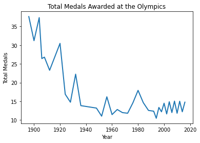

```python
#Visualizing the total amount of medals awarded throughout the years
plt.plot(total_ratio_medals.Year, total_ratio_medals.Total_Medals, marker='', linewidth = 2, label='Total Medals')
plt.xlabel("Year")
plt.ylabel("Total Medals")
plt.title("Total Medals Awarded at the Olympics")
```

This is very interesting seeing how many medals were awarded in the early years compared to now. It does make sense though considering how many participants competed in the early years(for example in 1900-1904 there were less than 2,000 people competing compared to current times we are looking at 13,000 olympians).

Similar to my intial research in my proposal there are aggressive spikes throughout the chart which relates to the switch between Summer Games and Winter Games every 2 years. To get a better view I will break this out into two seperate charts, Summer and Winter to give us a better visual representation of the data.

Theres an interesting spike in medals around 1980 which I will need to look into further to understand what this spike relates to.

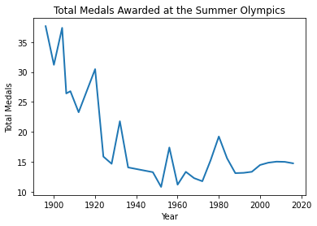

```python
#Visualizing the total amount of medals awarded throughout the years for the Summer Olympic Games

plt.plot(summer_ratio_medals.Year, summer_ratio_medals.Total_Medals, marker='', linewidth = 2, label='Total Medals')
plt.xlabel("Year")
plt.ylabel("Total Medals")
plt.title("Total Medals Awarded at the Summer Olympics")
```

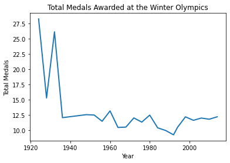

```python
#Visualizing the total amount of medals awarded throughout the years for the Winter Olympic Games

plt.plot(winter_ratio_medals.Year, winter_ratio_medals.Total_Medals, marker='', linewidth = 2, label='Total Medals')
plt.xlabel("Year")
plt.ylabel("Total Medals")
plt.title("Total Medals Awarded at the Winter Olympics")
```

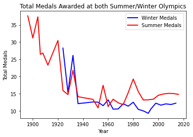

```python
#Comparing the medals awarded from the Summer games to Winter games

plt.plot(winter_ratio_medals.Year, winter_ratio_medals.Total_Medals, marker='', linewidth = 2, label='Winter Medals', color='Blue')
plt.plot(summer_ratio_medals.Year, summer_ratio_medals.Total_Medals, marker='', linewidth = 2, label='Summer Medals', color='Red')
plt.xlabel("Year")
plt.ylabel("Total Medals")
plt.legend(loc=1)
plt.title("Total Medals Awarded at both Summer/Winter Olympics")
```

Lets take a closer look at the medal % awarded throughout the year using subplots

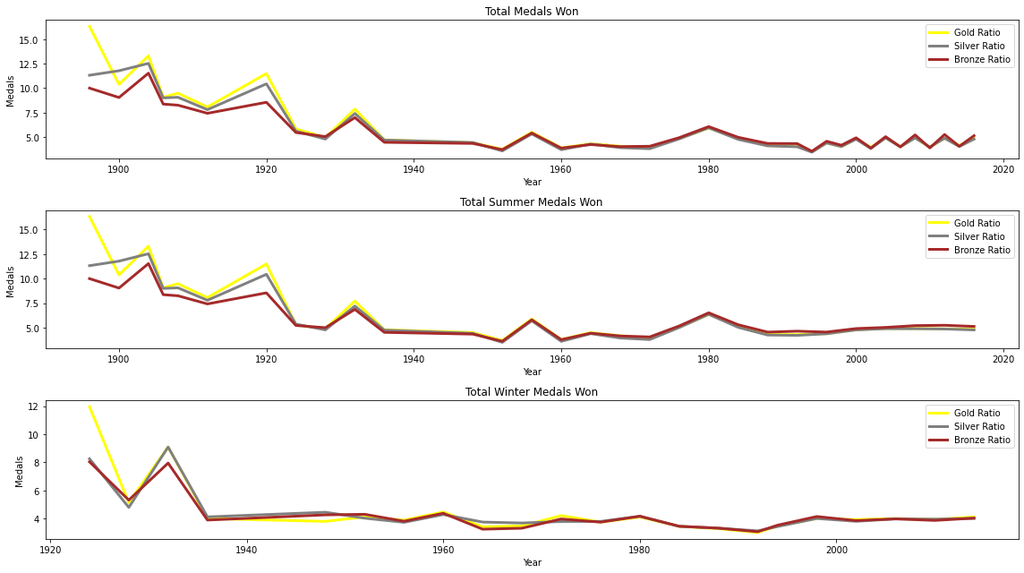

```python
fig, ax = plt.subplots(3, figsize=(16,9))
ax[0].plot(total_ratio_medals.Year, total_ratio_medals.Gold_Medals, marker='', color='Yellow', linewidth=3, label='Gold Ratio')
ax[0].plot(total_ratio_medals.Year, total_ratio_medals.Silver_Medals, marker='', color='Grey', linewidth=3, label='Silver Ratio')
ax[0].plot(total_ratio_medals.Year, total_ratio_medals.Bronze_Medals, marker='', color='Brown', linewidth=3, label='Bronze Ratio')
ax[0].legend(loc=1)
ax[0].set_xlabel("Year")
ax[0].set_ylabel("Medals")
ax[0].set_title("Total Medals Won")
ax[1].plot(summer_ratio_medals.Year, summer_ratio_medals.Gold_Medals, marker='', color='Yellow', linewidth=3, label='Gold Ratio')
ax[1].plot(summer_ratio_medals.Year, summer_ratio_medals.Silver_Medals, marker='', color='Grey', linewidth=3, label='Silver Ratio')
ax[1].plot(summer_ratio_medals.Year, summer_ratio_medals.Bronze_Medals, marker='', color='Brown', linewidth=3, label='Bronze Ratio')
ax[1].legend(loc=1)
ax[1].set_xlabel("Year")
ax[1].set_ylabel("Medals")
ax[1].set_title("Total Summer Medals Won")
ax[2].plot(winter_ratio_medals.Year, winter_ratio_medals.Gold_Medals, marker='', color='Yellow', linewidth=3, label='Gold Ratio')
ax[2].plot(winter_ratio_medals.Year, winter_ratio_medals.Silver_Medals, marker='', color='Grey', linewidth=3, label='Silver Ratio')
ax[2].plot(winter_ratio_medals.Year, winter_ratio_medals.Bronze_Medals, marker='', color='Brown', linewidth=3, label='Bronze Ratio')
ax[2].legend(loc=1)
ax[2].set_xlabel("Year")
ax[2].set_ylabel("Medals")
ax[2].set_title("Total Winter Medals Won")
plt.tight_layout()
```

As you can see from the above figures, in the early years there were different amounts of medals distributed for each class (gold, silver, bronze). Eventually this leveled out and it looks like the same amount of medals get distributed for gold, silver and bronze now but its interesting to see the difference compared to how it started.

# Submit 2-3 key points you may have discovered about the data, e.g. new relationships? Aha's! Did you come up with additional ideas for other things to review?

I discovered that there was a significant drop in the amount of medals awarded per the percentage of participants. If we look at the table below we can see that in the early years there was over 30% of participants awarded a medal of some kind whereas if we look at todays figures its dropped by around 50% with the amount of participants being awarded a medal ranging from 10% -15%.

```python
total_ratio_medals.head()
```

|  | Year | Total_Medals | Gold_Medals | Silver_Medals | Bronze_Medals |
| --- | --- | --- | --- | --- | --- |
| 0 | 1896 | 37.631579 | 16.315789 | 11.315789 | 10.000000 |
| 1 | 1900 | 31.198347 | 10.382231 | 11.776860 | 9.039256 |
| 2 | 1904 | 37.355880 | 13.297463 | 12.528824 | 11.529593 |
| 3 | 1906 | 26.428159 | 9.059435 | 9.001731 | 8.366994 |
| 4 | 1908 | 26.797807 | 9.480813 | 9.061593 | 8.255401 |

```python
total_ratio_medals.tail()
```

|  | Year | Total_Medals | Gold_Medals | Silver_Medals | Bronze_Medals |
| --- | --- | --- | --- | --- | --- |
| 30 | 2008 | 15.056609 | 4.933098 | 4.903691 | 5.219821 |
| 31 | 2010 | 11.812812 | 3.952749 | 3.975466 | 3.884598 |
| 32 | 2012 | 15.023220 | 4.891641 | 4.876161 | 5.255418 |
| 33 | 2014 | 12.206093 | 4.130035 | 4.027806 | 4.048252 |
| 34 | 2016 | 14.779369 | 4.858270 | 4.785213 | 5.135885 |

The total count of males vs females has started to level out in recent years but in the early years it was a huge discrepency. The toal participants for the past 120 years included 74,522 (27.48%) females and a dominating 196,594 (72.51%) being males.

As you can see from the graph below the difference is starting to improve and hopefully in the coming years it will be around 50/50.

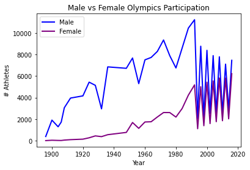

```python
plt.plot(male.Year, male.Male, marker='', color='blue', linewidth=2, label='Male')
plt.plot(female.Year, female.Female, marker='', color='purple', linewidth=2, label='Female')
plt.legend(loc=2)
plt.xlabel("Year")
plt.ylabel("# Athletes")
plt.title("Male vs Female Olympics Participation")
```

The third key point I noticed was how in the early years there were different amounts of medals distributed for each class (gold, silver, bronze). Eventually this leveled out and it looks like the same amount of medals get distributed for gold, silver and bronze now but its interesting to see the difference compared to how it started.

Subplot with the 3 graphs above will help put this into perspective.

I had one 'Aha' moment while looking into the dataset.

Theres an interesting spike in medals awarded around the year 1980 which I will need to look into further to understand what this spike relates to.

# Did you prove or disprove any of your initial hypotheses? If so, which one and what do you plan to do next?

1: I would think there are more men competing in the Olypmics currently but I am very interested in seeing how this has changed overtime and would think in current years it will be a lot more evenly divided. I was correct in thinking that there are more men competing currently in the olympics. I went into detail on this above but to summarize there was a huge gap in gender in the early years but it has been starting to level out ever since and more Women are competing from prior years. Eventually we will hopefully see this split level out completely and be 50/50.

2: Countries with the most medals are presuming to be the largest countries by population. e.g USA, China etc. I wasn't 100% correct on this assumption, U.S were leading by a significant amount but when it comes to countries behind them I was wrong which was why I wanted to review this dataset as I learned a lot. I then broke it down to see the Summer and Winter figures. Once again as expected for Summer games it was USA leading the pack. The winter games were led by Canada with USA coming in second and then followed by Scandavian countries such as Norway, Sweeden and Finland which is expected for the Winter games.

3: I would Imagine the age gap would be quite significant and will be interesting to see which sports they are most divided by. The age gap was very interesting to review as the youngest olympian to complete was only 10 years old which I was not aware of and the average age being from 20-30s.

# What additional questions are you seeking to answer?

Theres an interesting spike in medals awarded around the year 1980 which I will need to look into further to understand what this spike relates to.